# hw2

Jerry

February 8, 2020

```r
library(gapminder)
library(tidyverse)
```

Exercise 1

1.1 Use filter() to subset the gapminder data to three countries of your choice in the 1970’s.

```r
gapminder %>%
  filter(year < 1980 & year > 1970, country %in% c("Afghanistan", "Albania", "Algeria"))
```

```
## # A tibble: 6 x 6
##   country     continent  year lifeExp      pop gdpPercap
##   <fct>       <fct>     <int>   <dbl>    <int>     <dbl>
## 1 Afghanistan Asia       1972    36.1 13079460      740.
## 2 Afghanistan Asia       1977    38.4 14880372      786.
## 3 Albania     Europe     1972    67.7  2263554     3313.
## 4 Albania     Europe     1977    68.9  2509048     3533.
## 5 Algeria     Africa     1972    54.5 14760787     4183.
## 6 Algeria     Africa     1977    58.0 17152804     4910.
```

1.2 Use the pipe operator %>% to select “country” and “gdpPercap” from your filtered dataset in 1.1.

```r
gapminder %>%
  filter(year < 1980 & year > 1970, country %in% c("Afghanistan", "Albania", "Algeria")) %>%
  select('country', 'gdpPercap')
```

```
## # A tibble: 6 x 2
##   country     gdpPercap
##   <fct>           <dbl>
## 1 Afghanistan      740.
## 2 Afghanistan      786.
## 3 Albania         3313.
## 4 Albania         3533.
## 5 Algeria         4183.
## 6 Algeria         4910.
```

1.3 Filter gapminder to all entries that have experienced a drop in life expectancy. Be sure to include a new variable that’s the increase in life expectancy in your tibble.

Hint: you might find the lag() or diff() functions useful.

```r
library(tidyr)
```

```r
life_dec <- gapminder %>%
  arrange(year) %>%
  group_by(country) %>%
  mutate(lifeExp_dec = lifeExp - lag(lifeExp))
print(life_dec)
```

```
## # A tibble: 1,704 x 7
## # Groups:   country [142]
##    country     continent  year lifeExp      pop gdpPercap lifeExp_dec
##    <fct>       <fct>     <int>   <dbl>    <int>     <dbl>       <dbl>
##  1 Afghanistan Asia       1952    28.8  8425333      779.          NA
##  2 Albania     Europe     1952    55.2  1282697     1601.          NA
##  3 Algeria     Africa     1952    43.1  9279525     2449.          NA
##  4 Angola      Africa     1952    30.0  4232095     3521.          NA
##  5 Argentina   Americas   1952    62.5 17876956     5911.          NA
##  6 Australia   Oceania    1952    69.1  8691212    10040.          NA
##  7 Austria     Europe     1952    66.8  6927772     6137.          NA
##  8 Bahrain     Asia       1952    50.9   120447     9867.          NA
##  9 Bangladesh  Asia       1952    37.5 46886859      684.          NA
## 10 Belgium     Europe     1952    68    8730405     8343.          NA
## # ... with 1,694 more rows
```

```r
life_dec %>%
  tidyr::drop_na()
```

```
## # A tibble: 1,562 x 7
## # Groups:   country [142]
##    country     continent  year lifeExp      pop gdpPercap lifeExp_dec
##    <fct>       <fct>     <int>   <dbl>    <int>     <dbl>       <dbl>
##  1 Afghanistan Asia       1957    30.3  9240934      821.        1.53
##  2 Albania     Europe     1957    59.3  1476505     1942.        4.05
##  3 Algeria     Africa     1957    45.7 10270856     3014.        2.61
##  4 Angola      Africa     1957    32.0  4561361     3828.        1.98
##  5 Argentina   Americas   1957    64.4 19610538     6857.        1.91
##  6 Australia   Oceania    1957    70.3  9712569    10950.        1.21
##  7 Austria     Europe     1957    67.5  6965860     8843.        0.68
##  8 Bahrain     Asia       1957    53.8   138655    11636.        2.89
##  9 Bangladesh  Asia       1957    39.3 51365468      662.        1.86
## 10 Belgium     Europe     1957    69.2  8989111     9715.        1.24
## # ... with 1,552 more rows
```

1.4 Choose one of the following:

Filter gapminder so that it shows the max GDP per capita experienced by each country. Hint: you might find the max() function useful here.

Hint: you might find the sort() function useful, or perhaps even the dplyr::slice() function.

```r
gapminder %>%
group_by(country) %>%
summarise(max(gdpPercap))
```

```
## # A tibble: 142 x 2
##    country     `max(gdpPercap)`
##    <fct>                  <dbl>
##  1 Afghanistan             978.
##  2 Albania                5937.
##  3 Algeria                6223.
##  4 Angola                 5523.
##  5 Argentina             12779.
##  6 Australia             34435.
##  7 Austria               36126.
##  8 Bahrain               29796.
##  9 Bangladesh             1391.
## 10 Belgium               33693.
## # ... with 132 more rows
```

1.5 Produce a scatterplot of Canadaâs life expectancy vs. GDP per capita using ggplot2, without defining a new variable. That is, after filtering the gapminder data set, pipe it directly into the ggplot() function. Ensure GDP per capita is on a log scale.

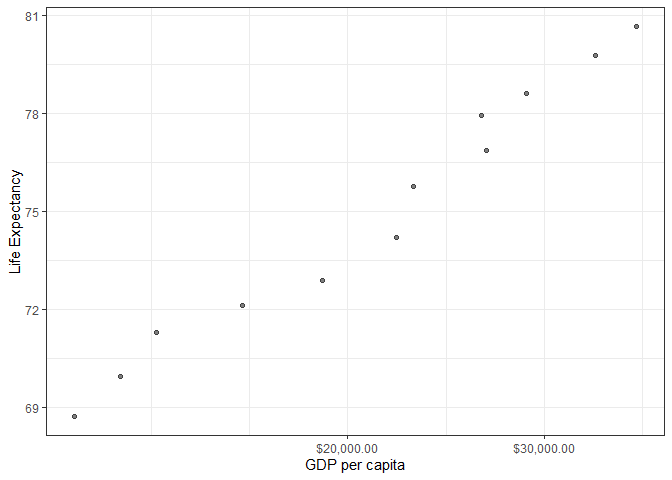

```r
gapminder %>%
  filter(country %in% c("Canada")) %>%
  select('lifeExp', 'gdpPercap') %>%
  ggplot(gapminder, mapping = aes(gdpPercap, lifeExp)) +
  geom_point(alpha = 0.5) +
  scale_x_log10("GDP per capita", labels = scales::dollar_format()) +
  theme_bw() +
  ylab("Life Expectancy")
```

Exercise 2 Pick one categorical variable and one quantitative variable to explore. Answer the following questions in whichever way you think is appropriate, using dplyr:

Range of values for life exepctancy.

```r
  range(gapminder$lifeExp)
```

```
## [1] 23.599 82.603
```

List of call continents

```r
unique(gapminder$continent)
```

```
## [1] Asia     Europe   Africa   Americas Oceania
## Levels: Africa Americas Asia Europe Oceania
```

Mean life expectancy

```r
dplyr::summarise(gapminder, avg = mean(lifeExp))
```

```
## # A tibble: 1 x 1
##     avg
##   <dbl>
## 1  59.5
```

Standard deviation of life expectancy

```r
dplyr::summarise(gapminder, sd = sd(lifeExp))
```

```
## # A tibble: 1 x 1
##      sd
##   <dbl>
## 1  12.9
```

Frequency of each continent

```r
dplyr::count(gapminder, continent)
```

```
## # A tibble: 5 x 2
##   continent     n
##   <fct>     <int>
## 1 Africa      624
## 2 Americas    300
## 3 Asia        396
## 4 Europe      360
## 5 Oceania      24
```

Exercise 3 Make two plots that have some value to them. That is, plots that someone might actually consider making for an analysis. Just donât make the same plots we made in classâfeel free to use a data set from the datasets R package or any other source if you wish.

A scatterplot of two quantitative variables. One other plot besides a scatterplot. You donât have to use all the data in every plot! Itâs fine to filter down to one group or country or a small handful of groups/countries.

```r
library(datasets)
```

Frequency of temperature found in each month in NYC in the summer of 1973. 5 = May, 9 = September. Temperature is in feirenheit.

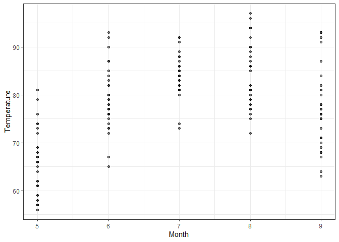

```r
  ggplot(airquality, mapping = aes(Month, Temp)) +
  geom_point(alpha = 0.5) +
  xlab("Month") +
  theme_bw() +
  ylab("Temperature")
```

Wind in mph taken from LaGuardia airport in 1973. Looks like June, July, and August are less windy months than May and September.

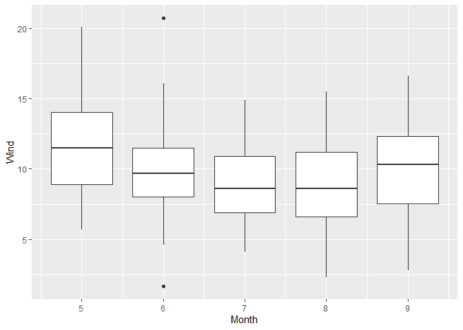

```r
airquality %>%
  ggplot(aes(Month, Wind)) +
  aes(group = Month)+
  geom_boxplot()
```

Recycling (Optional) (extra 2%) Rubrics:

Reasoning How well did you reason through the scenario? For people who want to take things further.

Evaluate this code and describe the result. Presumably the analystâs intent was to get the data for Rwanda and Afghanistan. Did they succeed? Why or why not? If not, what is the correct way to do this?

```r
filter(gapminder, country == c("Rwanda", "Afghanistan"))
```

```
## # A tibble: 12 x 6
##    country     continent  year lifeExp      pop gdpPercap
##    <fct>       <fct>     <int>   <dbl>    <int>     <dbl>
##  1 Afghanistan Asia       1957    30.3  9240934      821.
##  2 Afghanistan Asia       1967    34.0 11537966      836.
##  3 Afghanistan Asia       1977    38.4 14880372      786.
##  4 Afghanistan Asia       1987    40.8 13867957      852.
##  5 Afghanistan Asia       1997    41.8 22227415      635.
##  6 Afghanistan Asia       2007    43.8 31889923      975.
##  7 Rwanda      Africa     1952    40    2534927      493.
##  8 Rwanda      Africa     1962    43    3051242      597.
##  9 Rwanda      Africa     1972    44.6  3992121      591.
## 10 Rwanda      Africa     1982    46.2  5507565      882.
## 11 Rwanda      Africa     1992    23.6  7290203      737.
## 12 Rwanda      Africa     2002    43.4  7852401      786.
```

No, it looks like it pulls data where Afghanistan and Rwanda are on unique rows. When there is crossover data (when they share the same year), data is excluded. The best way to fix this would probably be this syntax:

```r
gapminder %>%
    filter( country %in% c("Afghanistan", "Rwanda"))
```

```
## # A tibble: 24 x 6
##    country     continent  year lifeExp      pop gdpPercap
##    <fct>       <fct>     <int>   <dbl>    <int>     <dbl>
##  1 Afghanistan Asia       1952    28.8  8425333      779.
##  2 Afghanistan Asia       1957    30.3  9240934      821.
##  3 Afghanistan Asia       1962    32.0 10267083      853.
##  4 Afghanistan Asia       1967    34.0 11537966      836.
##  5 Afghanistan Asia       1972    36.1 13079460      740.
##  6 Afghanistan Asia       1977    38.4 14880372      786.
##  7 Afghanistan Asia       1982    39.9 12881816      978.
##  8 Afghanistan Asia       1987    40.8 13867957      852.
##  9 Afghanistan Asia       1992    41.7 16317921      649.
## 10 Afghanistan Asia       1997    41.8 22227415      635.
## # ... with 14 more rows
```